# Bayesian Hierarchical Modeling of Physiological Responses

Jenna Lu

2026-07-27

# Overview

Physiological responses vary across individuals. A hierarchical modeling framework allows population-level effects to be estimated while accounting for participant-specific variability.

This notebook develops a Bayesian mixed-effects model for heart rate responses across participants in the WESAD dataset.

The goals are:

1. Construct a multi-subject physiological dataset
2. Model stress-related heart rate changes
3. Estimate uncertainty using Bayesian inference
4. Quantify individual differences in baseline physiology

# Libraries

```r
library(tidyverse)
library(here)
library(brms)
library(bayesplot)
library(posterior)
```

# Load Multi-Subject Data

The feature dataset generated in the previous analysis contains heart rate summaries across participants.

```r
features <- read_csv(
  here(
    "data",
    "processed",
    "multisubject_features.csv"
  )
)
head(features)
```

```
## # A tibble: 6 × 7
##   window mean_hr sd_hr max_hr min_hr label subject
##    <dbl>   <dbl> <dbl>  <dbl>  <dbl> <dbl> <chr>
## 1      0    95.3  6.77   106.   71.1     0 S10
## 2      1    92.5  7.87   107.   77.8     0 S10
## 3      2    94.8  5.29   106.   85.5     1 S10
## 4      3   101.   3.33   109.   94.4     1 S10
## 5      4   101.   8.24   113.   70.2     1 S10
## 6      5    96.2  3.82   104.   83.8     1 S10
```

# Create Stress Outcome

Stress corresponds to WESAD label 2.

```r
model_data <- features %>%
  mutate(
    stress = ifelse(
      label == 2,
      1,
      0
    )
  )


model_data %>%
  count(stress)
```

```
## # A tibble: 2 × 2
##   stress     n
##    <dbl> <int>
## 1      0  1050
## 2      1   155
```

# Explore Participant Variability

Participants exhibit different baseline heart rate distributions.

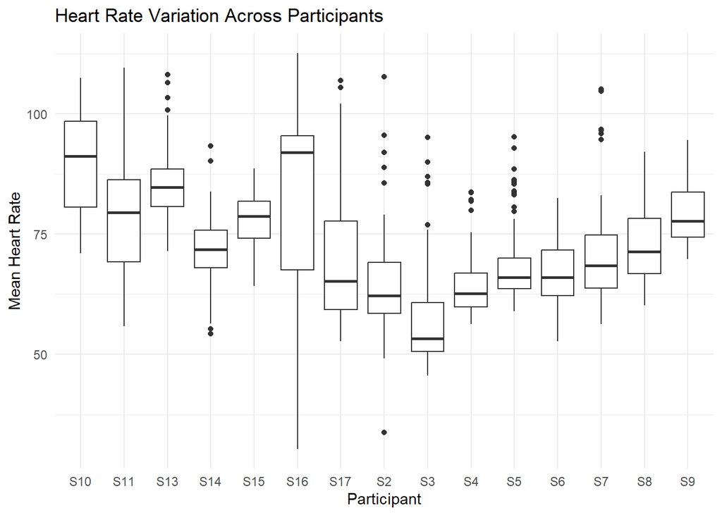

```r
model_data %>%
  ggplot(
    aes(
      x=subject,
      y=mean_hr
    )
  ) +
  geom_boxplot() +
  labs(
    title="Heart Rate Variation Across Participants",
    x="Participant",
    y="Mean Heart Rate"
  ) +
  theme_minimal()
```

# Bayesian Hierarchical Model

We model mean heart rate as a function of stress while allowing each participant to have their own baseline.

```r
bayes_model <- brm(

  mean_hr ~ stress +
    (1 | subject),

  data=model_data,

  family=gaussian(),

  prior=c(

    prior(
      normal(0,10),
      class="b"
    ),

    prior(
      exponential(1),
      class="sd"
    )

  ),

  chains=4,
  iter=2000,
  warmup=1000,
  seed=123

)
```

# Model Summary

```r
summary(bayes_model)
```

```
##  Family: gaussian
##   Links: mu = identity
## Formula: mean_hr ~ stress + (1 | subject)
##    Data: model_data (Number of observations: 1205)
##   Draws: 4 chains, each with iter = 2000; warmup = 1000; thin = 1;
##          total post-warmup draws = 4000
##
## Multilevel Hyperparameters:
## ~subject (Number of levels: 15)
##               Estimate Est.Error l-95% CI u-95% CI Rhat Bulk_ESS Tail_ESS
## sd(Intercept)     7.45      1.10     5.60     9.93 1.00      655     1246
##
## Regression Coefficients:
##           Estimate Est.Error l-95% CI u-95% CI Rhat Bulk_ESS Tail_ESS
## Intercept    72.38      1.90    68.64    75.93 1.01      419      632
## stress        6.97      0.81     5.41     8.53 1.00     2213     2199
##
## Further Distributional Parameters:
##       Estimate Est.Error l-95% CI u-95% CI Rhat Bulk_ESS Tail_ESS
## sigma     9.32      0.19     8.96     9.71 1.00     2089     2193
##
## Draws were sampled using sampling(NUTS). For each parameter, Bulk_ESS
## and Tail_ESS are effective sample size measures, and Rhat is the potential
## scale reduction factor on split chains (at convergence, Rhat = 1).
```

# Posterior Distributions

Bayesian inference provides full posterior distributions rather than only point estimates.

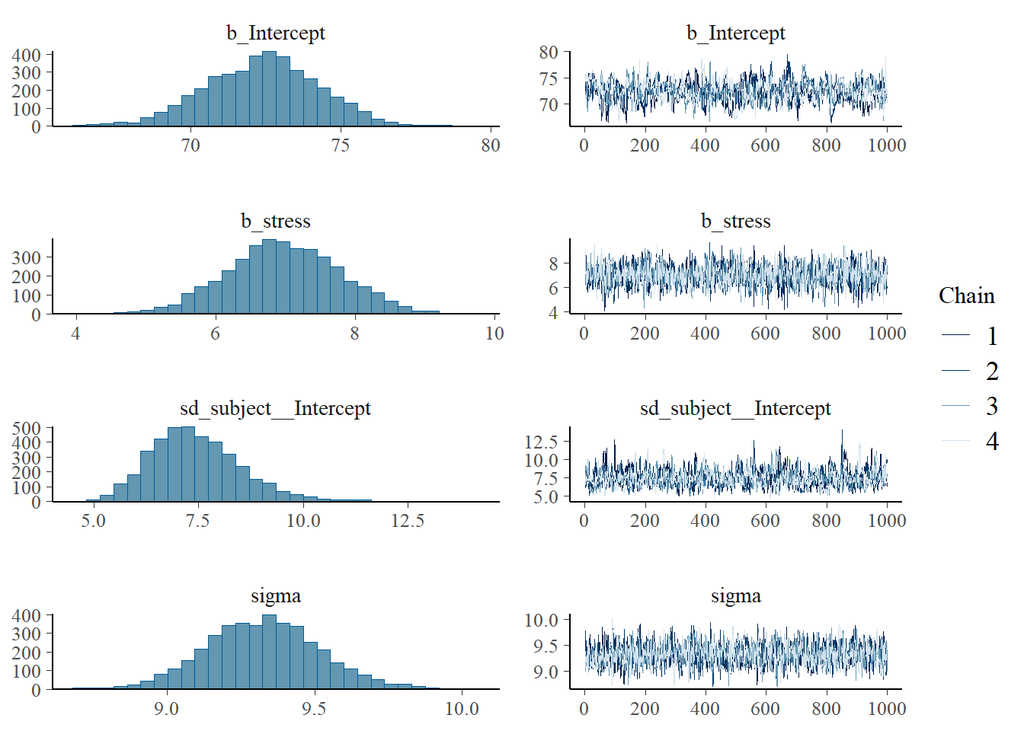

```r
plot(
  bayes_model
)
```

# Stress Effect Estimate

The stress coefficient represents the estimated change in heart rate associated with stress.

```r
posterior_samples <- posterior_samples(
  bayes_model
)
posterior_samples %>%
  select(
    b_stress
  ) %>%
  summary()
```

```
##     b_stress
##  Min.   :4.044
##  1st Qu.:6.431
##  Median :6.952
##  Mean   :6.968
##  3rd Qu.:7.521
##  Max.   :9.685
```

# Credible Interval Visualization

```r
mcmc_areas(
  posterior_samples,
  pars="b_stress"
)
```

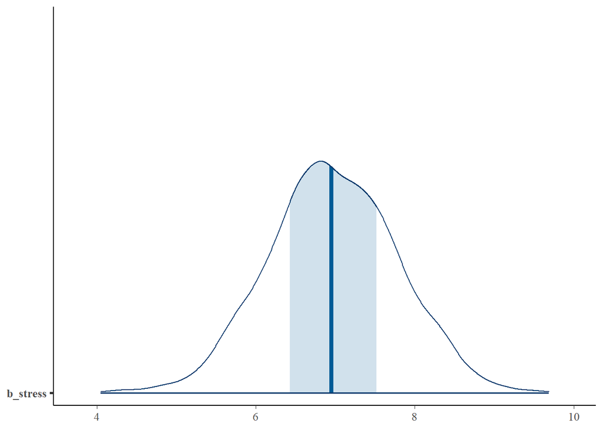

# Participant Random Effects

Individual baseline differences are captured through participant-level effects.

```r
ranef(bayes_model)
```

```
## $subject
## , , Intercept
##
##        Estimate Est.Error        Q2.5       Q97.5
## S10  16.3852822  2.113586  12.3724162  20.5578873
## S11   5.4789446  2.158887   1.3779478   9.6814481
## S13  12.1427191  2.096023   8.0833234  16.3109594
## S14  -1.7940330  2.185458  -6.1580416   2.4651877
## S15   4.4285655  2.092628   0.3728927   8.5421379
## S16   8.0297732  2.497389   3.2052239  12.9929535
## S17  -3.4344600  2.094764  -7.2942343   0.8133587
## S2   -7.9439637  2.235598 -12.1995907  -3.5730717
## S3  -15.9236228  2.145532 -20.2410976 -11.7376186
## S4   -8.8528598  2.083054 -12.8652716  -4.7498793
## S5   -4.5524592  2.085286  -8.6028235  -0.3835519
## S6   -5.9164391  2.132135 -10.1040868  -1.6847109
## S7   -2.7922746  2.111353  -6.7255790   1.3736074
## S8   -0.3146876  2.091109  -4.3106225   3.7766081
## S9    5.9032742  2.088262   1.8566932   9.9923123
```

# Posterior Predictive Checking

We evaluate whether simulated data from the model resemble observed physiological patterns.

```r
pp_check(
  bayes_model
)
```

```
## Using 10 posterior draws for ppc type 'dens_overlay' by default.
```

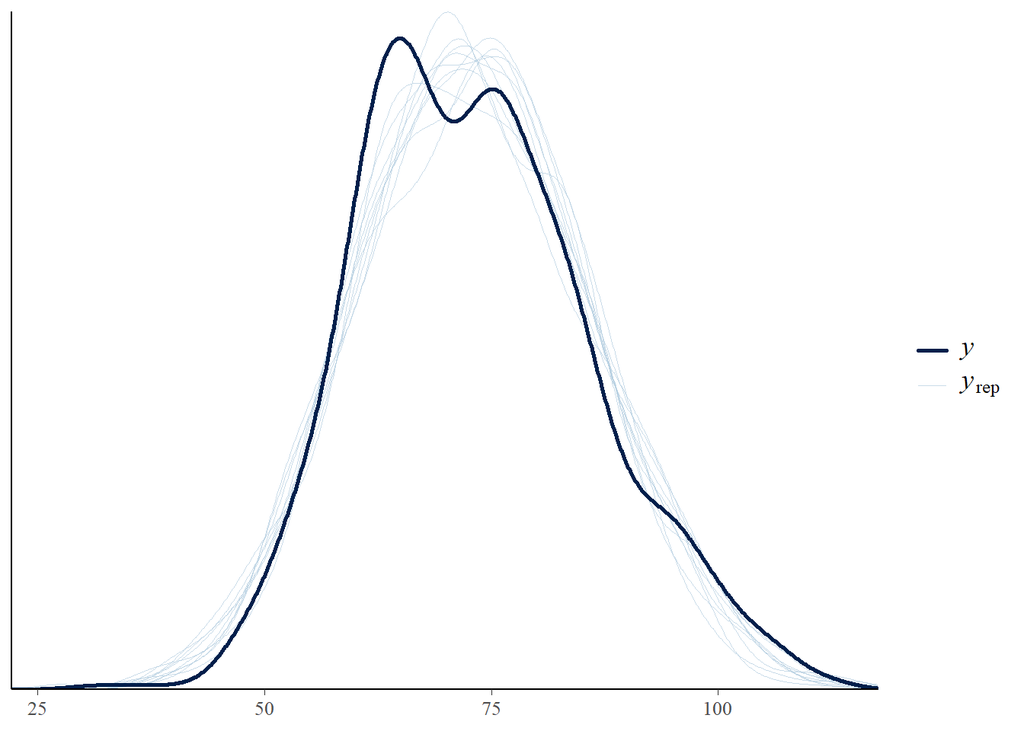

# Summary

This analysis demonstrates Bayesian hierarchical modeling of physiological signals.

The model:

- estimates population-level stress effects
- accounts for individual physiological differences
- quantifies uncertainty through posterior distributions
- provides a framework for personalized biomedical modeling

Future extensions include:

- Bayesian functional regression
- time-varying hierarchical models
- multimodal EEG and ECG integration
- personalized physiological prediction